# Part II - Ford GoBike Bike Sharing Data Exploration

## Dataset Overview

This dataset consists of information about individual rides made in the month of Febuary 2019 by Ford GoBike (Currently named Bay Wheels).

This dataset has 183,412 observations(entries) across 16 features(columns). The features of this dataset include

- Duration of bike rent(seconds),
- Time of rent(including date),
- Time of return of bike(including date,
- Start Station ID
- Start Station Name
- End Station ID
- End Station Name
- Latitude & Longitude of Both Start and End Stations
- Bike ID
- User Type ( Subscriber / Customer)
- Birth Year of User
- User Gender
- Bike Share For All Trip

## Distribution of User Types in the dataset.

About **90.5%** of users are subscribers as opposed to **9.5%** who use the service on a pay per use basis. This suggest that as at feburary 2019, the service has been useful enough to users that almost all it's users were willing to use it on a subscritiption basis.

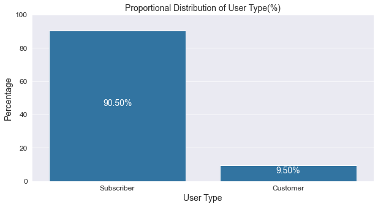

## Age distribution of Users

It appears the majority of users fall within the ages of 20 and 40, with a substantial amount falling between 40 and 60.

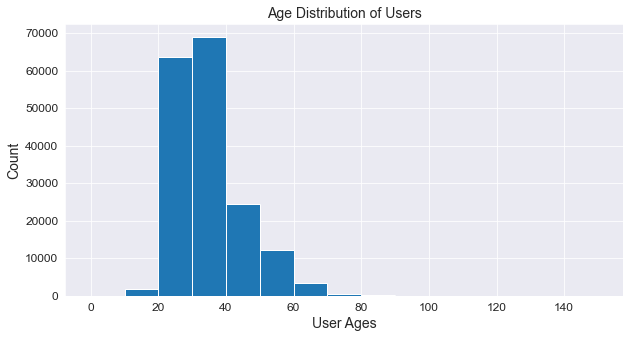

## How long do users rent the bikes for

Most of the users rent the bikes for less than an hour. Drilling into the 1 hour rent period shows that most user rent the bike for roughly 12 minutes on average and generally less than 30 minutes

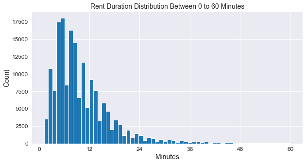

## Time Period Distribution of Renting and Returning of Bikes

It appears most people rent the bikes in the morning followed by night time. We also see this trend in when people return the bikes most.

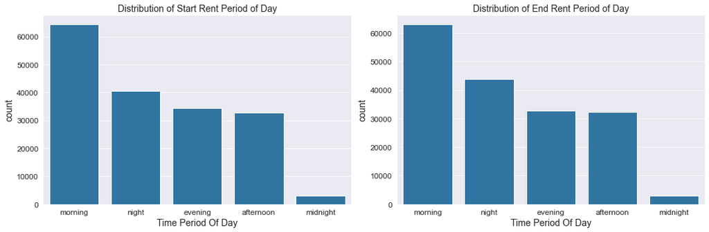

## Relationship Between User Ages and Time Period of Rent and Return

As suggested previously, most of the users fall between the ages of 20-40yrs old and the bulk of the 25-30+ years rent and return the bikes in the mornings and at night.

This seems to fit the hypotesis that a good numbers of the users use the service to commute to & fro from work

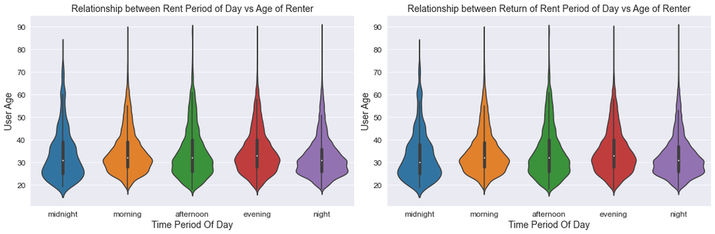

## Relationships between User Type,Rent Duration and Gender

It appears those who are subscribed to the service use it for lesser rent hours as compared to those who pay for it on a per service usage rate. This might suggest that those who are subscribed to the service have a fixed short distance route they need the service for. This follows with my earlier hypotesis that many people might be using the service for their daily commute to and fro from work or business. It also appears that on average, male users rent the bikes for a shorter period than other users across board

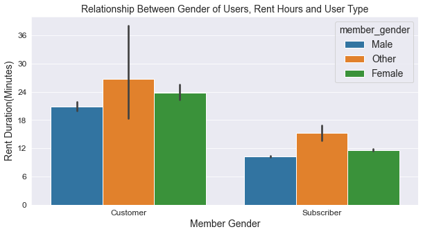